# Data Preparation

# Introduction

Before applying `nuggets` for pattern discovery, data columns intended as predicates must be prepared either by *dichotomization* (conversion into *dummy variables*) or by transformation into *fuzzy sets*. This vignette provides a comprehensive guide to data preparation functions and techniques available in the `nuggets` package.

The package provides two main approaches for data preparation:

1. **Crisp (Boolean) predicates**: Transform data columns into logical (`TRUE`/`FALSE`) columns. This approach is simpler and faster, and is recommended for most applications.
2. **Fuzzy predicates**: Transform numeric columns into membership degrees in the interval $[0, 1]$. This approach is more flexible and allows modeling of uncertainty in data, but is more computationally demanding.

The primary function for data preparation is `partition()`, which handles both crisp and fuzzy transformations. Additional utility functions help identify and remove uninformative columns and detect tautologies in the data.

Before going further, ensure that all packages required for this vignette are loaded:

```r
library(nuggets)
library(dplyr)    # for data manipulation
library(tidyr)    # for even more data manipulation
library(ggplot2)  # for graphical visualization
```

# Data Preparation with `partition()`

For patterns based on crisp conditions, the data columns that serve as predicates in conditions must be transformed either to logical (`TRUE`/`FALSE`) columns, or to fuzzy sets with values from the interval $[0, 1]$. The first option is simpler and faster, and it is the recommended option for most applications. The second option is more flexible and allows to model uncertainty in data, but it is more computationally demanding.

Throughout this section, we use a modified version of the built-in `mtcars` dataset for illustration. We transform the `cyl` column into a factor and the `vs` column into a logical:

```r
mtcars_example <- mtcars
mtcars_example$cyl <- factor(mtcars_example$cyl,
                     levels= c(4, 6, 8),
                     labels = c("four", "six", "eight"))
mtcars_example$vs <- as.logical(mtcars_example$vs)
head(mtcars_example)
```

```
#>                    mpg   cyl disp  hp drat    wt  qsec    vs am gear carb
#> Mazda RX4         21.0   six  160 110 3.90 2.620 16.46 FALSE  1    4    4
#> Mazda RX4 Wag     21.0   six  160 110 3.90 2.875 17.02 FALSE  1    4    4
#> Datsun 710        22.8  four  108  93 3.85 2.320 18.61  TRUE  1    4    1
#> Hornet 4 Drive    21.4   six  258 110 3.08 3.215 19.44  TRUE  0    3    1
#> Hornet Sportabout 18.7 eight  360 175 3.15 3.440 17.02 FALSE  0    3    2
#> Valiant           18.1   six  225 105 2.76 3.460 20.22  TRUE  0    3    1
```

## Preparation of Predicates from Logical Columns

Logical columns are automatically transformed to dummy logical columns by the `partition()` function without the need to specify any additional arguments. A logical column `x` is expanded into two predicates: `x=T` for rows where `x` is `TRUE` and `x=F` for rows where `x` is `FALSE`. Missing values are excluded from both predicates.

The `partition()` function requires the dataset as its first argument and a [tidyselect expression](https://tidyselect.r-lib.org/reference/language.html) to select the columns to be transformed. For example, the `vs` column in `mtcars_example` is a logical column indicating the engine type (V-shaped or straight):

```r
partition(mtcars_example, vs)
```

```
#> # A tibble: 32 × 12
#>      mpg cyl    disp    hp  drat    wt  qsec    am  gear  carb `vs=T` `vs=F`
#>    <dbl> <fct> <dbl> <dbl> <dbl> <dbl> <dbl> <dbl> <dbl> <dbl> <lgl>  <lgl>
#>  1  21   six    160    110  3.9   2.62  16.5     1     4     4 FALSE  TRUE
#>  2  21   six    160    110  3.9   2.88  17.0     1     4     4 FALSE  TRUE
#>  3  22.8 four   108     93  3.85  2.32  18.6     1     4     1 TRUE   FALSE
#>  4  21.4 six    258    110  3.08  3.22  19.4     0     3     1 TRUE   FALSE
#>  5  18.7 eight  360    175  3.15  3.44  17.0     0     3     2 FALSE  TRUE
#>  6  18.1 six    225    105  2.76  3.46  20.2     0     3     1 TRUE   FALSE
#>  7  14.3 eight  360    245  3.21  3.57  15.8     0     3     4 FALSE  TRUE
#>  8  24.4 four   147.    62  3.69  3.19  20       0     4     2 TRUE   FALSE
#>  9  22.8 four   141.    95  3.92  3.15  22.9     0     4     2 TRUE   FALSE
#> 10  19.2 six    168.   123  3.92  3.44  18.3     0     4     4 TRUE   FALSE
#> # ℹ 22 more rows
```

## Preparation of Predicates from Factors

Factor columns are expanded into logical predicates representing subsets of their levels. By default, one predicate per level is created (`.subsets = 1`).

The `cyl` column in `mtcars_example` is a factor with three levels. Factors are transformed to dummy logical columns by the `partition()` function automatically:

```r
partition(mtcars_example, cyl)
```

```
#> # A tibble: 32 × 13
#>      mpg  disp    hp  drat    wt  qsec vs       am  gear  carb `cyl=four`
#>    <dbl> <dbl> <dbl> <dbl> <dbl> <dbl> <lgl> <dbl> <dbl> <dbl> <lgl>
#>  1  21    160    110  3.9   2.62  16.5 FALSE     1     4     4 FALSE
#>  2  21    160    110  3.9   2.88  17.0 FALSE     1     4     4 FALSE
#>  3  22.8  108     93  3.85  2.32  18.6 TRUE      1     4     1 TRUE
#>  4  21.4  258    110  3.08  3.22  19.4 TRUE      0     3     1 FALSE
#>  5  18.7  360    175  3.15  3.44  17.0 FALSE     0     3     2 FALSE
#>  6  18.1  225    105  2.76  3.46  20.2 TRUE      0     3     1 FALSE
#>  7  14.3  360    245  3.21  3.57  15.8 FALSE     0     3     4 FALSE
#>  8  24.4  147.    62  3.69  3.19  20   TRUE      0     4     2 TRUE
#>  9  22.8  141.    95  3.92  3.15  22.9 TRUE      0     4     2 TRUE
#> 10  19.2  168.   123  3.92  3.44  18.3 TRUE      0     4     4 FALSE
#>    `cyl=six` `cyl=eight`
#>    <lgl>     <lgl>
#>  1 TRUE      FALSE
#>  2 TRUE      FALSE
#>  3 FALSE     FALSE
#>  4 TRUE      FALSE
#>  5 FALSE     TRUE
#>  6 TRUE      FALSE
#>  7 FALSE     TRUE
#>  8 FALSE     FALSE
#>  9 FALSE     FALSE
#> 10 TRUE      FALSE
#> # ℹ 22 more rows
```

It is also possible to create predicates that represent **merged factor levels** by setting the `.subsets` argument to larger values. This is useful when you want to explore patterns involving combinations of categories.

The `.subsets` argument specifies the sizes of level subsets for which predicates should be created:

- For **unordered** factors, all subsets of the requested sizes are created.
- For **ordered** factors, only subsets formed by **consecutive** levels are created.
- Subset sizes equal to the total number of levels are rejected, because they would produce a predicate that is always `TRUE` for all non-missing values.

For example, `cyl` is an unordered factor with three levels:

```r
# Default: one predicate per level
partition(mtcars_example, cyl)
```

```
#> # A tibble: 32 × 13
#>      mpg  disp    hp  drat    wt  qsec vs       am  gear  carb `cyl=four`
#>    <dbl> <dbl> <dbl> <dbl> <dbl> <dbl> <lgl> <dbl> <dbl> <dbl> <lgl>
#>  1  21    160    110  3.9   2.62  16.5 FALSE     1     4     4 FALSE
#>  2  21    160    110  3.9   2.88  17.0 FALSE     1     4     4 FALSE
#>  3  22.8  108     93  3.85  2.32  18.6 TRUE      1     4     1 TRUE
#>  4  21.4  258    110  3.08  3.22  19.4 TRUE      0     3     1 FALSE
#>  5  18.7  360    175  3.15  3.44  17.0 FALSE     0     3     2 FALSE
#>  6  18.1  225    105  2.76  3.46  20.2 TRUE      0     3     1 FALSE
#>  7  14.3  360    245  3.21  3.57  15.8 FALSE     0     3     4 FALSE
#>  8  24.4  147.    62  3.69  3.19  20   TRUE      0     4     2 TRUE
#>  9  22.8  141.    95  3.92  3.15  22.9 TRUE      0     4     2 TRUE
#> 10  19.2  168.   123  3.92  3.44  18.3 TRUE      0     4     4 FALSE
#>    `cyl=six` `cyl=eight`
#>    <lgl>     <lgl>
#>  1 TRUE      FALSE
#>  2 TRUE      FALSE
#>  3 FALSE     FALSE
#>  4 TRUE      FALSE
#>  5 FALSE     TRUE
#>  6 TRUE      FALSE
#>  7 FALSE     TRUE
#>  8 FALSE     FALSE
#>  9 FALSE     FALSE
#> 10 TRUE      FALSE
#> # ℹ 22 more rows
```

```r
# Merge pairs of levels - all pairs are created for unordered factors
partition(mtcars_example, cyl, .subsets = 2)
```

```
#> # A tibble: 32 × 13
#>      mpg  disp    hp  drat    wt  qsec vs       am  gear  carb `cyl=four,six`
#>    <dbl> <dbl> <dbl> <dbl> <dbl> <dbl> <lgl> <dbl> <dbl> <dbl> <lgl>
#>  1  21    160    110  3.9   2.62  16.5 FALSE     1     4     4 TRUE
#>  2  21    160    110  3.9   2.88  17.0 FALSE     1     4     4 TRUE
#>  3  22.8  108     93  3.85  2.32  18.6 TRUE      1     4     1 TRUE
#>  4  21.4  258    110  3.08  3.22  19.4 TRUE      0     3     1 TRUE
#>  5  18.7  360    175  3.15  3.44  17.0 FALSE     0     3     2 FALSE
#>  6  18.1  225    105  2.76  3.46  20.2 TRUE      0     3     1 TRUE
#>  7  14.3  360    245  3.21  3.57  15.8 FALSE     0     3     4 FALSE
#>  8  24.4  147.    62  3.69  3.19  20   TRUE      0     4     2 TRUE
#>  9  22.8  141.    95  3.92  3.15  22.9 TRUE      0     4     2 TRUE
#> 10  19.2  168.   123  3.92  3.44  18.3 TRUE      0     4     4 TRUE
#>    `cyl=four,eight` `cyl=six,eight`
#>    <lgl>            <lgl>
#>  1 FALSE            TRUE
#>  2 FALSE            TRUE
#>  3 TRUE             FALSE
#>  4 FALSE            TRUE
#>  5 TRUE             TRUE
#>  6 FALSE            TRUE
#>  7 TRUE             TRUE
#>  8 TRUE             FALSE
#>  9 TRUE             FALSE
#> 10 FALSE            TRUE
#> # ℹ 22 more rows
```

```r
# Create both individual and merged predicates
partition(mtcars_example, cyl, .subsets = c(1, 2))
```

```
#> # A tibble: 32 × 16
#>      mpg  disp    hp  drat    wt  qsec vs       am  gear  carb `cyl=four`
#>    <dbl> <dbl> <dbl> <dbl> <dbl> <dbl> <lgl> <dbl> <dbl> <dbl> <lgl>
#>  1  21    160    110  3.9   2.62  16.5 FALSE     1     4     4 FALSE
#>  2  21    160    110  3.9   2.88  17.0 FALSE     1     4     4 FALSE
#>  3  22.8  108     93  3.85  2.32  18.6 TRUE      1     4     1 TRUE
#>  4  21.4  258    110  3.08  3.22  19.4 TRUE      0     3     1 FALSE
#>  5  18.7  360    175  3.15  3.44  17.0 FALSE     0     3     2 FALSE
#>  6  18.1  225    105  2.76  3.46  20.2 TRUE      0     3     1 FALSE
#>  7  14.3  360    245  3.21  3.57  15.8 FALSE     0     3     4 FALSE
#>  8  24.4  147.    62  3.69  3.19  20   TRUE      0     4     2 TRUE
#>  9  22.8  141.    95  3.92  3.15  22.9 TRUE      0     4     2 TRUE
#> 10  19.2  168.   123  3.92  3.44  18.3 TRUE      0     4     4 FALSE
#>    `cyl=six` `cyl=eight` `cyl=four,six` `cyl=four,eight` `cyl=six,eight`
#>    <lgl>     <lgl>       <lgl>          <lgl>            <lgl>
#>  1 TRUE      FALSE       TRUE           FALSE            TRUE
#>  2 TRUE      FALSE       TRUE           FALSE            TRUE
#>  3 FALSE     FALSE       TRUE           TRUE             FALSE
#>  4 TRUE      FALSE       TRUE           FALSE            TRUE
#>  5 FALSE     TRUE        FALSE          TRUE             TRUE
#>  6 TRUE      FALSE       TRUE           FALSE            TRUE
#>  7 FALSE     TRUE        FALSE          TRUE             TRUE
#>  8 FALSE     FALSE       TRUE           TRUE             FALSE
#>  9 FALSE     FALSE       TRUE           TRUE             FALSE
#> 10 TRUE      FALSE       TRUE           FALSE            TRUE
#> # ℹ 22 more rows
```

For ordered factors, only consecutive levels are merged. To illustrate, let us create an ordered version of the `cyl` column:

```r
mtcars_example$cyl_ord <- ordered(mtcars$cyl,
                                  levels = c(4, 6, 8),
                                  labels = c("four", "six", "eight"))

# Default: one predicate per level
partition(mtcars_example, cyl_ord)
```

```
#> # A tibble: 32 × 14
#>      mpg cyl    disp    hp  drat    wt  qsec vs       am  gear  carb
#>    <dbl> <fct> <dbl> <dbl> <dbl> <dbl> <dbl> <lgl> <dbl> <dbl> <dbl>
#>  1  21   six    160    110  3.9   2.62  16.5 FALSE     1     4     4
#>  2  21   six    160    110  3.9   2.88  17.0 FALSE     1     4     4
#>  3  22.8 four   108     93  3.85  2.32  18.6 TRUE      1     4     1
#>  4  21.4 six    258    110  3.08  3.22  19.4 TRUE      0     3     1
#>  5  18.7 eight  360    175  3.15  3.44  17.0 FALSE     0     3     2
#>  6  18.1 six    225    105  2.76  3.46  20.2 TRUE      0     3     1
#>  7  14.3 eight  360    245  3.21  3.57  15.8 FALSE     0     3     4
#>  8  24.4 four   147.    62  3.69  3.19  20   TRUE      0     4     2
#>  9  22.8 four   141.    95  3.92  3.15  22.9 TRUE      0     4     2
#> 10  19.2 six    168.   123  3.92  3.44  18.3 TRUE      0     4     4
#>    `cyl_ord=four` `cyl_ord=six` `cyl_ord=eight`
#>    <lgl>          <lgl>         <lgl>
#>  1 FALSE          TRUE          FALSE
#>  2 FALSE          TRUE          FALSE
#>  3 TRUE           FALSE         FALSE
#>  4 FALSE          TRUE          FALSE
#>  5 FALSE          FALSE         TRUE
#>  6 FALSE          TRUE          FALSE
#>  7 FALSE          FALSE         TRUE
#>  8 TRUE           FALSE         FALSE
#>  9 TRUE           FALSE         FALSE
#> 10 FALSE          TRUE          FALSE
#> # ℹ 22 more rows
```

```r
# Only consecutive pairs are created for ordered factors
partition(mtcars_example, cyl_ord, .subsets = 2)
```

```
#> # A tibble: 32 × 13
#>      mpg cyl    disp    hp  drat    wt  qsec vs       am  gear  carb
#>    <dbl> <fct> <dbl> <dbl> <dbl> <dbl> <dbl> <lgl> <dbl> <dbl> <dbl>
#>  1  21   six    160    110  3.9   2.62  16.5 FALSE     1     4     4
#>  2  21   six    160    110  3.9   2.88  17.0 FALSE     1     4     4
#>  3  22.8 four   108     93  3.85  2.32  18.6 TRUE      1     4     1
#>  4  21.4 six    258    110  3.08  3.22  19.4 TRUE      0     3     1
#>  5  18.7 eight  360    175  3.15  3.44  17.0 FALSE     0     3     2
#>  6  18.1 six    225    105  2.76  3.46  20.2 TRUE      0     3     1
#>  7  14.3 eight  360    245  3.21  3.57  15.8 FALSE     0     3     4
#>  8  24.4 four   147.    62  3.69  3.19  20   TRUE      0     4     2
#>  9  22.8 four   141.    95  3.92  3.15  22.9 TRUE      0     4     2
#> 10  19.2 six    168.   123  3.92  3.44  18.3 TRUE      0     4     4
#>    `cyl_ord=four,six` `cyl_ord=six,eight`
#>    <lgl>              <lgl>
#>  1 TRUE               TRUE
#>  2 TRUE               TRUE
#>  3 TRUE               FALSE
#>  4 TRUE               TRUE
#>  5 FALSE              TRUE
#>  6 TRUE               TRUE
#>  7 FALSE              TRUE
#>  8 TRUE               FALSE
#>  9 TRUE               FALSE
#> 10 TRUE               TRUE
#> # ℹ 22 more rows
```

```r
# Both individual levels and consecutive pairs
partition(mtcars_example, cyl_ord, .subsets = c(1, 2))
```

```
#> # A tibble: 32 × 16
#>      mpg cyl    disp    hp  drat    wt  qsec vs       am  gear  carb
#>    <dbl> <fct> <dbl> <dbl> <dbl> <dbl> <dbl> <lgl> <dbl> <dbl> <dbl>
#>  1  21   six    160    110  3.9   2.62  16.5 FALSE     1     4     4
#>  2  21   six    160    110  3.9   2.88  17.0 FALSE     1     4     4
#>  3  22.8 four   108     93  3.85  2.32  18.6 TRUE      1     4     1
#>  4  21.4 six    258    110  3.08  3.22  19.4 TRUE      0     3     1
#>  5  18.7 eight  360    175  3.15  3.44  17.0 FALSE     0     3     2
#>  6  18.1 six    225    105  2.76  3.46  20.2 TRUE      0     3     1
#>  7  14.3 eight  360    245  3.21  3.57  15.8 FALSE     0     3     4
#>  8  24.4 four   147.    62  3.69  3.19  20   TRUE      0     4     2
#>  9  22.8 four   141.    95  3.92  3.15  22.9 TRUE      0     4     2
#> 10  19.2 six    168.   123  3.92  3.44  18.3 TRUE      0     4     4
#>    `cyl_ord=four` `cyl_ord=six` `cyl_ord=eight` `cyl_ord=four,six`
#>    <lgl>          <lgl>         <lgl>           <lgl>
```

[output cut: 23 more lines]

This feature can be very useful for discovering patterns where multiple categories together form a meaningful group. For instance, in a dataset with an education level factor, merging “bachelor” and “master” into a single predicate might reveal patterns associated with “higher education” in general.

For more details on factor column handling, see `?partition`.

## Preparation of Crisp Predicates from Numeric Columns

For numeric columns, the `partition()` function requires the `.method` argument to specify the method of partitioning:

- `.method = "dummy"` transforms numeric columns to factors and then to dummy logical columns. That effectively creates a separate logical column for each distinct value of the numeric column.
- `.method = "crisp"` transforms numeric columns to crisp predicates by dividing the range of values into intervals and coding the values into dummy logical columns according to the intervals.
- there exist other methods of partitioning of numeric columns. These methods create fuzzy predicates and are described in the next section.

The `am` and `gear` columns in `mtcars_example` are numeric but actually represent categories. To transform them to dummy logical columns in the same way as factors, we can use the `partition()` function with the `.method` argument set to `"dummy"`:

```r
partition(mtcars_example, am:gear, .method = "dummy")
```

```
#> # A tibble: 32 × 15
#>      mpg cyl    disp    hp  drat    wt  qsec vs     carb cyl_ord `am=0` `am=1`
#>    <dbl> <fct> <dbl> <dbl> <dbl> <dbl> <dbl> <lgl> <dbl> <ord>   <lgl>  <lgl>
#>  1  21   six    160    110  3.9   2.62  16.5 FALSE     4 six     FALSE  TRUE
#>  2  21   six    160    110  3.9   2.88  17.0 FALSE     4 six     FALSE  TRUE
#>  3  22.8 four   108     93  3.85  2.32  18.6 TRUE      1 four    FALSE  TRUE
#>  4  21.4 six    258    110  3.08  3.22  19.4 TRUE      1 six     TRUE   FALSE
#>  5  18.7 eight  360    175  3.15  3.44  17.0 FALSE     2 eight   TRUE   FALSE
#>  6  18.1 six    225    105  2.76  3.46  20.2 TRUE      1 six     TRUE   FALSE
#>  7  14.3 eight  360    245  3.21  3.57  15.8 FALSE     4 eight   TRUE   FALSE
#>  8  24.4 four   147.    62  3.69  3.19  20   TRUE      2 four    TRUE   FALSE
#>  9  22.8 four   141.    95  3.92  3.15  22.9 TRUE      2 four    TRUE   FALSE
#> 10  19.2 six    168.   123  3.92  3.44  18.3 TRUE      4 six     TRUE   FALSE
#>    `gear=3` `gear=4` `gear=5`
#>    <lgl>    <lgl>    <lgl>
#>  1 FALSE    TRUE     FALSE
#>  2 FALSE    TRUE     FALSE
#>  3 FALSE    TRUE     FALSE
#>  4 TRUE     FALSE    FALSE
#>  5 TRUE     FALSE    FALSE
#>  6 TRUE     FALSE    FALSE
#>  7 TRUE     FALSE    FALSE
#>  8 FALSE    TRUE     FALSE
#>  9 FALSE    TRUE     FALSE
#> 10 FALSE    TRUE     FALSE
#> # ℹ 22 more rows
```

The `"crisp"` method divides the range of values of the selected columns into intervals specified by the `.breaks` argument and then encodes the values into dummy logical columns corresponding to the intervals. The `.breaks` argument is a numeric vector that specifies the interval boundaries.

For example, the `mpg` values can be divided into four intervals: (-Inf, 15], (15, 20], (20, 30], and (30, Inf). The `.breaks` argument is then the vector `c(-Inf, 15, 20, 30, Inf)`, which defines the boundaries of these intervals.

```r
partition(mtcars_example, mpg, .method = "crisp", .breaks = c(-Inf, 15, 20, 30, Inf))
```

```
#> # A tibble: 32 × 15
#>    cyl    disp    hp  drat    wt  qsec vs       am  gear  carb cyl_ord
#>    <fct> <dbl> <dbl> <dbl> <dbl> <dbl> <lgl> <dbl> <dbl> <dbl> <ord>
#>  1 six    160    110  3.9   2.62  16.5 FALSE     1     4     4 six
#>  2 six    160    110  3.9   2.88  17.0 FALSE     1     4     4 six
#>  3 four   108     93  3.85  2.32  18.6 TRUE      1     4     1 four
#>  4 six    258    110  3.08  3.22  19.4 TRUE      0     3     1 six
#>  5 eight  360    175  3.15  3.44  17.0 FALSE     0     3     2 eight
#>  6 six    225    105  2.76  3.46  20.2 TRUE      0     3     1 six
#>  7 eight  360    245  3.21  3.57  15.8 FALSE     0     3     4 eight
#>  8 four   147.    62  3.69  3.19  20   TRUE      0     4     2 four
#>  9 four   141.    95  3.92  3.15  22.9 TRUE      0     4     2 four
#> 10 six    168.   123  3.92  3.44  18.3 TRUE      0     4     4 six
#>    `mpg=(-Inf;15]` `mpg=(15;20]` `mpg=(20;30]` `mpg=(30;Inf]`
#>    <lgl>           <lgl>         <lgl>         <lgl>
#>  1 FALSE           FALSE         TRUE          FALSE
#>  2 FALSE           FALSE         TRUE          FALSE
#>  3 FALSE           FALSE         TRUE          FALSE
#>  4 FALSE           FALSE         TRUE          FALSE
#>  5 FALSE           TRUE          FALSE         FALSE
#>  6 FALSE           TRUE          FALSE         FALSE
#>  7 TRUE            FALSE         FALSE         FALSE
#>  8 FALSE           FALSE         TRUE          FALSE
#>  9 FALSE           FALSE         TRUE          FALSE
#> 10 FALSE           TRUE          FALSE         FALSE
#> # ℹ 22 more rows
```

Note: it is advisable to put `-Inf` and `Inf` as the first and last elements of the `.breaks` vector to ensure that all values are covered by the intervals.

If we want the breaks to be evenly spaced across the range of values, we can set `.breaks` to a single integer. This value specifies the number of intervals to create. For example, the following command divides the `disp` values into three intervals of equal width:

```r
partition(mtcars_example, disp, .method = "crisp", .breaks = 3)
```

```
#> # A tibble: 32 × 14
#>      mpg cyl      hp  drat    wt  qsec vs       am  gear  carb cyl_ord
#>    <dbl> <fct> <dbl> <dbl> <dbl> <dbl> <lgl> <dbl> <dbl> <dbl> <ord>
#>  1  21   six     110  3.9   2.62  16.5 FALSE     1     4     4 six
#>  2  21   six     110  3.9   2.88  17.0 FALSE     1     4     4 six
#>  3  22.8 four     93  3.85  2.32  18.6 TRUE      1     4     1 four
#>  4  21.4 six     110  3.08  3.22  19.4 TRUE      0     3     1 six
#>  5  18.7 eight   175  3.15  3.44  17.0 FALSE     0     3     2 eight
#>  6  18.1 six     105  2.76  3.46  20.2 TRUE      0     3     1 six
#>  7  14.3 eight   245  3.21  3.57  15.8 FALSE     0     3     4 eight
#>  8  24.4 four     62  3.69  3.19  20   TRUE      0     4     2 four
#>  9  22.8 four     95  3.92  3.15  22.9 TRUE      0     4     2 four
#> 10  19.2 six     123  3.92  3.44  18.3 TRUE      0     4     4 six
#>    `disp=(-Inf;205]` `disp=(205;338]` `disp=(338;Inf]`
#>    <lgl>             <lgl>            <lgl>
#>  1 TRUE              FALSE            FALSE
#>  2 TRUE              FALSE            FALSE
#>  3 TRUE              FALSE            FALSE
#>  4 FALSE             TRUE             FALSE
#>  5 FALSE             FALSE            TRUE
#>  6 FALSE             TRUE             FALSE
#>  7 FALSE             FALSE            TRUE
#>  8 TRUE              FALSE            FALSE
#>  9 TRUE              FALSE            FALSE
#> 10 TRUE              FALSE            FALSE
#> # ℹ 22 more rows
```

Each call to `partition()` returns a tibble with the selected columns transformed to dummy logical columns, while the other columns remain unchanged.

The transformation of the whole `mtcars` dataset to crisp predicates can be done as follows:

```r
crisp_mtcars <- mtcars_example |>
    partition(cyl, cyl_ord, am:gear, .method = "dummy") |>
    partition(vs) |>
    partition(mpg, .method = "crisp", .breaks = c(-Inf, 15, 20, 30, Inf)) |>
    partition(disp:carb, .method = "crisp", .breaks = 3)

head(crisp_mtcars, n = 3)
```

```
#> # A tibble: 3 × 35
#>   `cyl=four` `cyl=six` `cyl=eight` `cyl_ord=four` `cyl_ord=six` `cyl_ord=eight`
#>   <lgl>      <lgl>     <lgl>       <lgl>          <lgl>         <lgl>
#> 1 FALSE      TRUE      FALSE       FALSE          TRUE          FALSE
#> 2 FALSE      TRUE      FALSE       FALSE          TRUE          FALSE
#> 3 TRUE       FALSE     FALSE       TRUE           FALSE         FALSE
#>   `am=0` `am=1` `gear=3` `gear=4` `gear=5` `vs=T` `vs=F` `mpg=(-Inf;15]`
#>   <lgl>  <lgl>  <lgl>    <lgl>    <lgl>    <lgl>  <lgl>  <lgl>
#> 1 FALSE  TRUE   FALSE    TRUE     FALSE    FALSE  TRUE   FALSE
#> 2 FALSE  TRUE   FALSE    TRUE     FALSE    FALSE  TRUE   FALSE
#> 3 FALSE  TRUE   FALSE    TRUE     FALSE    TRUE   FALSE  FALSE
#>   `mpg=(15;20]` `mpg=(20;30]` `mpg=(30;Inf]` `disp=(-Inf;205]` `disp=(205;338]`
#>   <lgl>         <lgl>         <lgl>          <lgl>             <lgl>
#> 1 FALSE         TRUE          FALSE          TRUE              FALSE
#> 2 FALSE         TRUE          FALSE          TRUE              FALSE
#> 3 FALSE         TRUE          FALSE          TRUE              FALSE
#>   `disp=(338;Inf]` `hp=(-Inf;146]` `hp=(146;241]` `hp=(241;Inf]`
#>   <lgl>            <lgl>           <lgl>          <lgl>
#> 1 FALSE            TRUE            FALSE          FALSE
#> 2 FALSE            TRUE            FALSE          FALSE
#> 3 FALSE            TRUE            FALSE          FALSE
#>   `drat=(-Inf;3.48]` `drat=(3.48;4.21]` `drat=(4.21;Inf]` `wt=(-Inf;2.82]`
#>   <lgl>              <lgl>              <lgl>             <lgl>
#> 1 FALSE              TRUE               FALSE             TRUE
#> 2 FALSE              TRUE               FALSE             FALSE
#> 3 FALSE              TRUE               FALSE             TRUE
#>   `wt=(2.82;4.12]` `wt=(4.12;Inf]` `qsec=(-Inf;17.3]` `qsec=(17.3;20.1]`
#>   <lgl>            <lgl>           <lgl>              <lgl>
#> 1 FALSE            FALSE           TRUE               FALSE
#> 2 TRUE             FALSE           TRUE               FALSE
#> 3 FALSE            FALSE           FALSE              TRUE
#>   `qsec=(20.1;Inf]` `carb=(-Inf;3.33]` `carb=(3.33;5.67]` `carb=(5.67;Inf]`
#>   <lgl>             <lgl>              <lgl>              <lgl>
#> 1 FALSE             FALSE              TRUE               FALSE
#> 2 FALSE             FALSE              TRUE               FALSE
#> 3 FALSE             TRUE               FALSE              FALSE
```

Now all columns are logical and can be used as predicates in crisp conditions.

### Data-Driven Breakpoint Selection with `.style`

When `.breaks` is specified as a single integer (the number of intervals), the `partition()` function can use various data-driven methods to determine optimal breakpoints, rather than simply dividing the range into equal-width intervals. This is controlled by the `.style` argument, which leverages methods from the `classInt` package.

The `.style` argument supports the following methods:

- **`"equal"`** (default) – equal-width intervals across the column range
- **`"quantile"`** – equal-frequency intervals (quantile-based)
- **`"kmeans"`** – intervals found by 1D k-means clustering
- **`"sd"`** – intervals based on standard deviations from the mean
- **`"hclust"`** – hierarchical clustering intervals
- **`"bclust"`** – model-based clustering intervals
- **`"fisher"`** / **`"jenks"`** – Fisher–Jenks optimal partitioning
- **`"dpih"`** – kernel-based density partitioning
- **`"headtails"`** – head/tails natural breaks
- **`"maximum"`** – maximization-based partitioning
- **`"box"`** – breaks at boxplot hinges

These methods are particularly useful when the data distribution is skewed or has natural clusters. For example, quantile-based partitioning ensures that each interval contains approximately the same number of observations, which can be valuable for imbalanced datasets.

Here are examples using the CO2 dataset:

```r
# Equal-width intervals (default)
partition(CO2, conc, .method = "crisp", .breaks = 4, .style = "equal")
```

```
#> # A tibble: 84 × 8
#>    Plant Type   Treatment  uptake `conc=(-Inf;321]` `conc=(321;548]`
#>    <ord> <fct>  <fct>       <dbl> <lgl>             <lgl>
#>  1 Qn1   Quebec nonchilled   16   TRUE              FALSE
#>  2 Qn1   Quebec nonchilled   30.4 TRUE              FALSE
#>  3 Qn1   Quebec nonchilled   34.8 TRUE              FALSE
#>  4 Qn1   Quebec nonchilled   37.2 FALSE             TRUE
#>  5 Qn1   Quebec nonchilled   35.3 FALSE             TRUE
#>  6 Qn1   Quebec nonchilled   39.2 FALSE             FALSE
#>  7 Qn1   Quebec nonchilled   39.7 FALSE             FALSE
#>  8 Qn2   Quebec nonchilled   13.6 TRUE              FALSE
#>  9 Qn2   Quebec nonchilled   27.3 TRUE              FALSE
#> 10 Qn2   Quebec nonchilled   37.1 TRUE              FALSE
#>    `conc=(548;774]` `conc=(774;Inf]`
#>    <lgl>            <lgl>
#>  1 FALSE            FALSE
#>  2 FALSE            FALSE
#>  3 FALSE            FALSE
#>  4 FALSE            FALSE
#>  5 FALSE            FALSE
#>  6 TRUE             FALSE
#>  7 FALSE            TRUE
#>  8 FALSE            FALSE
#>  9 FALSE            FALSE
#> 10 FALSE            FALSE
#> # ℹ 74 more rows
```

```r
# Quantile-based intervals (equal frequency in each interval)
partition(CO2, conc, .method = "crisp", .breaks = 4, .style = "quantile")
```

```
#> # A tibble: 84 × 8
#>    Plant Type   Treatment  uptake `conc=(-Inf;175]` `conc=(175;350]`
#>    <ord> <fct>  <fct>       <dbl> <lgl>             <lgl>
#>  1 Qn1   Quebec nonchilled   16   TRUE              FALSE
#>  2 Qn1   Quebec nonchilled   30.4 TRUE              FALSE
#>  3 Qn1   Quebec nonchilled   34.8 FALSE             TRUE
#>  4 Qn1   Quebec nonchilled   37.2 FALSE             TRUE
#>  5 Qn1   Quebec nonchilled   35.3 FALSE             FALSE
#>  6 Qn1   Quebec nonchilled   39.2 FALSE             FALSE
#>  7 Qn1   Quebec nonchilled   39.7 FALSE             FALSE
#>  8 Qn2   Quebec nonchilled   13.6 TRUE              FALSE
#>  9 Qn2   Quebec nonchilled   27.3 TRUE              FALSE
#> 10 Qn2   Quebec nonchilled   37.1 FALSE             TRUE
#>    `conc=(350;675]` `conc=(675;Inf]`
#>    <lgl>            <lgl>
#>  1 FALSE            FALSE
#>  2 FALSE            FALSE
#>  3 FALSE            FALSE
#>  4 FALSE            FALSE
#>  5 TRUE             FALSE
#>  6 TRUE             FALSE
#>  7 FALSE            TRUE
#>  8 FALSE            FALSE
#>  9 FALSE            FALSE
#> 10 FALSE            FALSE
#> # ℹ 74 more rows
```

```r
# K-means clustering to find natural breakpoints
partition(CO2, conc, .method = "crisp", .breaks = 4, .style = "kmeans")
```

```
#> # A tibble: 84 × 8
#>    Plant Type   Treatment  uptake `conc=(-Inf;135]` `conc=(135;300]`
#>    <ord> <fct>  <fct>       <dbl> <lgl>             <lgl>
#>  1 Qn1   Quebec nonchilled   16   TRUE              FALSE
#>  2 Qn1   Quebec nonchilled   30.4 FALSE             TRUE
#>  3 Qn1   Quebec nonchilled   34.8 FALSE             TRUE
#>  4 Qn1   Quebec nonchilled   37.2 FALSE             FALSE
#>  5 Qn1   Quebec nonchilled   35.3 FALSE             FALSE
#>  6 Qn1   Quebec nonchilled   39.2 FALSE             FALSE
#>  7 Qn1   Quebec nonchilled   39.7 FALSE             FALSE
#>  8 Qn2   Quebec nonchilled   13.6 TRUE              FALSE
#>  9 Qn2   Quebec nonchilled   27.3 FALSE             TRUE
#> 10 Qn2   Quebec nonchilled   37.1 FALSE             TRUE
#>    `conc=(300;588]` `conc=(588;Inf]`
#>    <lgl>            <lgl>
#>  1 FALSE            FALSE
#>  2 FALSE            FALSE
#>  3 FALSE            FALSE
#>  4 TRUE             FALSE
#>  5 TRUE             FALSE
#>  6 FALSE            TRUE
#>  7 FALSE            TRUE
#>  8 FALSE            FALSE
#>  9 FALSE            FALSE
#> 10 FALSE            FALSE
#> # ℹ 74 more rows
```

```r
# Standard deviation-based intervals
partition(CO2, conc, .method = "crisp", .breaks = 4, .style = "sd")
```

```
#> # A tibble: 84 × 8
#>    Plant Type   Treatment  uptake `conc=(-Inf;139]` `conc=(139;435]`
#>    <ord> <fct>  <fct>       <dbl> <lgl>             <lgl>
#>  1 Qn1   Quebec nonchilled   16   TRUE              FALSE
#>  2 Qn1   Quebec nonchilled   30.4 FALSE             TRUE
#>  3 Qn1   Quebec nonchilled   34.8 FALSE             TRUE
#>  4 Qn1   Quebec nonchilled   37.2 FALSE             TRUE
#>  5 Qn1   Quebec nonchilled   35.3 FALSE             FALSE
#>  6 Qn1   Quebec nonchilled   39.2 FALSE             FALSE
#>  7 Qn1   Quebec nonchilled   39.7 FALSE             FALSE
#>  8 Qn2   Quebec nonchilled   13.6 TRUE              FALSE
#>  9 Qn2   Quebec nonchilled   27.3 FALSE             TRUE
#> 10 Qn2   Quebec nonchilled   37.1 FALSE             TRUE
#>    `conc=(435;731]` `conc=(731;Inf]`
#>    <lgl>            <lgl>
#>  1 FALSE            FALSE
#>  2 FALSE            FALSE
#>  3 FALSE            FALSE
#>  4 FALSE            FALSE
#>  5 TRUE             FALSE
#>  6 TRUE             FALSE
#>  7 FALSE            TRUE
#>  8 FALSE            FALSE
#>  9 FALSE            FALSE
#> 10 FALSE            FALSE
#> # ℹ 74 more rows
```

The `.style_params` argument allows you to pass additional parameters to the underlying algorithm. This should be a named list of arguments accepted by the respective method in `classInt::classIntervals()`.

For example, when using k-means clustering, you can specify the algorithm:

```r
# Use Lloyd's algorithm for k-means
partition(CO2, conc, .method = "crisp", .breaks = 4,
          .style = "kmeans",
          .style_params = list(algorithm = "Lloyd"))
```

```
#> # A tibble: 84 × 8
#>    Plant Type   Treatment  uptake `conc=(-Inf;425]` `conc=(425;588]`
#>    <ord> <fct>  <fct>       <dbl> <lgl>             <lgl>
#>  1 Qn1   Quebec nonchilled   16   TRUE              FALSE
#>  2 Qn1   Quebec nonchilled   30.4 TRUE              FALSE
#>  3 Qn1   Quebec nonchilled   34.8 TRUE              FALSE
#>  4 Qn1   Quebec nonchilled   37.2 TRUE              FALSE
#>  5 Qn1   Quebec nonchilled   35.3 FALSE             TRUE
#>  6 Qn1   Quebec nonchilled   39.2 FALSE             FALSE
#>  7 Qn1   Quebec nonchilled   39.7 FALSE             FALSE
#>  8 Qn2   Quebec nonchilled   13.6 TRUE              FALSE
#>  9 Qn2   Quebec nonchilled   27.3 TRUE              FALSE
#> 10 Qn2   Quebec nonchilled   37.1 TRUE              FALSE
#>    `conc=(588;838]` `conc=(838;Inf]`
#>    <lgl>            <lgl>
#>  1 FALSE            FALSE
#>  2 FALSE            FALSE
#>  3 FALSE            FALSE
#>  4 FALSE            FALSE
#>  5 FALSE            FALSE
#>  6 TRUE             FALSE
#>  7 FALSE            TRUE
#>  8 FALSE            FALSE
#>  9 FALSE            FALSE
#> 10 FALSE            FALSE
#> # ℹ 74 more rows
```

When using quantile-based intervals, you can control the quantile type:

```r
# Use different quantile types (see ?quantile for details)
partition(CO2, conc, .method = "crisp", .breaks = 4,
          .style = "quantile",
          .style_params = list(type = 7))
```

```
#> # A tibble: 84 × 8
#>    Plant Type   Treatment  uptake `conc=(-Inf;175]` `conc=(175;350]`
#>    <ord> <fct>  <fct>       <dbl> <lgl>             <lgl>
#>  1 Qn1   Quebec nonchilled   16   TRUE              FALSE
#>  2 Qn1   Quebec nonchilled   30.4 TRUE              FALSE
#>  3 Qn1   Quebec nonchilled   34.8 FALSE             TRUE
#>  4 Qn1   Quebec nonchilled   37.2 FALSE             TRUE
#>  5 Qn1   Quebec nonchilled   35.3 FALSE             FALSE
#>  6 Qn1   Quebec nonchilled   39.2 FALSE             FALSE
#>  7 Qn1   Quebec nonchilled   39.7 FALSE             FALSE
#>  8 Qn2   Quebec nonchilled   13.6 TRUE              FALSE
#>  9 Qn2   Quebec nonchilled   27.3 TRUE              FALSE
#> 10 Qn2   Quebec nonchilled   37.1 FALSE             TRUE
#>    `conc=(350;675]` `conc=(675;Inf]`
#>    <lgl>            <lgl>
#>  1 FALSE            FALSE
#>  2 FALSE            FALSE
#>  3 FALSE            FALSE
#>  4 FALSE            FALSE
#>  5 TRUE             FALSE
#>  6 TRUE             FALSE
#>  7 FALSE            TRUE
#>  8 FALSE            FALSE
#>  9 FALSE            FALSE
#> 10 FALSE            FALSE
#> # ℹ 74 more rows
```

These data-driven methods can produce more meaningful intervals that better reflect the structure of your data, leading to more interpretable patterns in subsequent analysis.

## Preparation of Fuzzy Predicates from Numeric Columns

In many real-world datasets, numeric attributes do not lend themselves to clear-cut, crisp boundaries. For example, deciding whether a car has “low mileage” or “high mileage” is often subjective. A vehicle with 19 miles per gallon may be considered “low” in one context but “medium” in another. Crisp intervals force a strict separation between categories, which can be too rigid and may lose information about gradual changes in the data.

To address this, **fuzzy predicates** are used. A fuzzy predicate expresses the degree to which a condition is satisfied. Instead of being strictly `TRUE` or `FALSE` (although allowed too), each predicate is represented by a number in the interval $[0,1]$. A truth degree of 0 means the predicate is entirely false, 1 means it is fully true, and values in between indicate partial membership. This allows us to model smooth transitions between categories and capture more nuanced patterns.

For example, a fuzzy predicate could represent “medium horsepower” in the `mtcars` dataset. A car with 120 hp may belong to this category to a degree of 0.8, while a car with 150 hp may belong to it only to a degree of 0.2. Such representations are more faithful to human reasoning and often yield patterns that are both more robust and more interpretable.

The transformation of numeric columns to fuzzy predicates can be done with the `partition()` function. As with crisp partitioning, factors are transformed to dummy logical columns. Numeric columns, however, are transformed into *fuzzy truth values*. The `partition()` function provides two fuzzy partitioning methods:

- `.method = "triangle"` creates fuzzy sets with triangular or trapezoidal membership functions;
- `.method = "raisedcos"` creates fuzzy sets with raised cosine or trapezoidal raised-cosine membership functions.

These membership functions specify how strongly a value belongs to a fuzzy set. The choice of function depends on the desired smoothness of the transition between sets.

> More advanced fuzzy partitioning of numeric columns can be achieved with the lfl package, which provides tools for defining fuzzy sets of many types, including linguistic terms such as “very small” or “extremely big”. See the [`lfl` documentation](https://github.com/beerda/lfl/blob/master/vignettes/main.pdf) for more information.

Both triangular and raised cosine shapes are fully defined by three points: the left border, the peak, and the right border. The `.breaks` argument in the `partition()` function specifies these points. See the following figure for an illustration of triangular and raised cosine membership functions for `.breaks = c(-10, 0, 10)`:

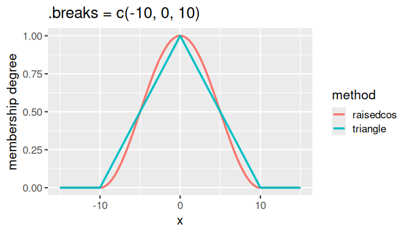

Comparison of triangular and raised cosine membership functions for `.breaks = c(-10, 0, 10)`

Each consecutive triplet of values in `.breaks` defines one fuzzy set. To create e.g. three fuzzy sets, five break points are needed. For instance, `.breaks = c(-10, -5, 0, 5, 10)` defines three fuzzy sets with peaks at -5, 0, and 5. See the following figure for an illustration of these fuzzy sets:

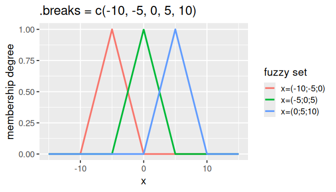

Fuzzy sets with triangular membership functions for `partition(x, .method = "triangle", .breaks = c(-10, -5, 0, 5, 10))`

It is often useful to extend the fuzzy sets on the edges to infinity. That ensures that all values are covered by the fuzzy sets. To achieve that, `-Inf` and `Inf` can be added as the first and last elements of the `.breaks` vector:

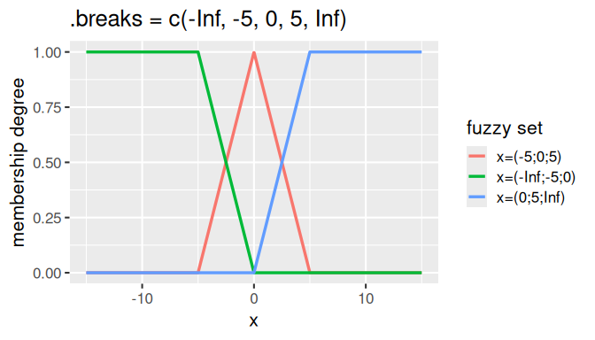

Fuzzy sets with triangular membership functions for `partition(x, .method = "triangle", .breaks = c(-Inf, -5, 0, 5, Inf))`

If a regular partitioning of the range of values is desired, `.breaks` can be set to a single integer, which specifies the number of fuzzy sets to create. For example, `.breaks = 4` creates partitioning with four fuzzy sets:

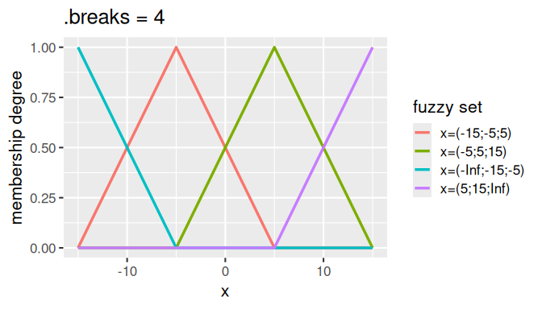

Fuzzy sets with triangular membership functions for `partition(x, .method = "triangle", .breaks = 4)`

The same is valid for raised cosine fuzzy sets. For instance, the following figure shows five raised cosine fuzzy sets defined by `.breaks = c(-Inf, -10, -5, 0, 5, 10, Inf)`:

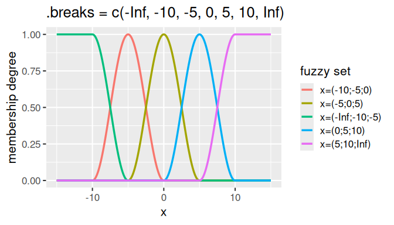

Fuzzy sets with raised cosine membership functions for `partition(x, .method = "raisedcos", .breaks = c(-Inf, -10, -5, 0, 5, 10, Inf))`

A fuzzy transformation of the whole `mtcars` dataset can be done as follows:

```r
# Start with a fresh copy of mtcars
fuzzy_mtcars <- mtcars |>
    mutate(cyl = factor(cyl, levels = c(4, 6, 8), labels = c("four", "six", "eight"))) |>
    partition(cyl, vs:gear, .method = "dummy") |>
    partition(mpg, .method = "triangle", .breaks = c(-Inf, 15, 20, 30, Inf)) |>
    partition(disp:carb, .method = "triangle", .breaks = 3)

head(fuzzy_mtcars, n = 3)
```

```
#> # A tibble: 3 × 31
#>   `cyl=four` `cyl=six` `cyl=eight` `vs=0` `vs=1` `am=0` `am=1` `gear=3` `gear=4`
#>   <lgl>      <lgl>     <lgl>       <lgl>  <lgl>  <lgl>  <lgl>  <lgl>    <lgl>
#> 1 FALSE      TRUE      FALSE       TRUE   FALSE  FALSE  TRUE   FALSE    TRUE
#> 2 FALSE      TRUE      FALSE       TRUE   FALSE  FALSE  TRUE   FALSE    TRUE
#> 3 TRUE       FALSE     FALSE       FALSE  TRUE   FALSE  TRUE   FALSE    TRUE
#>   `gear=5` `mpg=(-Inf;15;20)` `mpg=(15;20;30)` `mpg=(20;30;Inf)`
#>   <lgl>                 <dbl>            <dbl>             <dbl>
#> 1 FALSE                     0             0.9               0.1
#> 2 FALSE                     0             0.9               0.1
#> 3 FALSE                     0             0.72              0.28
#>   `disp=(-Inf;71.1;272)` `disp=(71.1;272;472)` `disp=(272;472;Inf)`
#>                    <dbl>                 <dbl>                <dbl>
#> 1                  0.557                 0.443                    0
#> 2                  0.557                 0.443                    0
#> 3                  0.816                 0.184                    0
#>   `hp=(-Inf;52;194)` `hp=(52;194;335)` `hp=(194;335;Inf)`
#>                <dbl>             <dbl>              <dbl>
#> 1              0.592             0.408                  0
#> 2              0.592             0.408                  0
#> 3              0.711             0.289                  0
#>   `drat=(-Inf;2.76;3.84)` `drat=(2.76;3.84;4.93)` `drat=(3.84;4.93;Inf)`
#>                     <dbl>                   <dbl>                  <dbl>
#> 1                       0                   0.945                0.0550
#> 2                       0                   0.945                0.0550
#> 3                       0                   0.991                0.00917
#>   `wt=(-Inf;1.51;3.47)` `wt=(1.51;3.47;5.42)` `wt=(3.47;5.42;Inf)`
#>                   <dbl>                 <dbl>                <dbl>
#> 1                 0.434                 0.566                    0
#> 2                 0.304                 0.696                    0
#> 3                 0.587                 0.413                    0
#>   `qsec=(-Inf;14.5;18.7)` `qsec=(14.5;18.7;22.9)` `qsec=(18.7;22.9;Inf)`
#>                     <dbl>                   <dbl>                  <dbl>
#> 1                  0.533                    0.467                      0
#> 2                  0.4                      0.6                        0
#> 3                  0.0214                   0.979                      0
#>   `carb=(-Inf;1;4.5)` `carb=(1;4.5;8)` `carb=(4.5;8;Inf)`
#>                 <dbl>            <dbl>              <dbl>
#> 1               0.143            0.857                  0
#> 2               0.143            0.857                  0
#> 3               1                0                      0
```

Note that the `cyl`, `vs`, `am`, and `gear` columns are still represented by dummy logical columns, while the `mpg`, `disp`, and other columns are now represented by fuzzy sets. This combination allows both crisp and fuzzy predicates to be used together in pattern discovery, offering more flexibility and interpretability.

### Trapezoidal Fuzzy Predicates

The triangular and raised cosine membership functions are often sufficient to capture gradual transitions in numeric data. However, in some situations it is useful to have fuzzy sets that stay *fully true (membership = 1)* over a wider interval before decreasing again. This generalization corresponds to a *trapezoidal fuzzy set*, which can be seen as a triangle or raised cosine with a “flat top”.

With `partition()`, trapezoids can be defined for both `"triangle"` and `"raisedcos"` methods by controlling how many consecutive break points constitute one fuzzy set and how far the window shifts along the breaks. That can be accomplished with the `.span` and `.inc` arguments:

- `.span` - specifies the width of the flat top in terms of the number of break intervals that should be merged.
- `.inc` - the shift of the window along `.breaks` when forming the next fuzzy set.

By default, `.span = 1` and `.inc = 1`, which means that each fuzzy set is triangular or raised cosine. Setting `.span` to a value greater than 1 creates trapezoidal fuzzy sets. With `.span = 2`, each fuzzy set is defined by four consecutive break points - a flat top spans two break intervals. The following figure is the result of setting `.span = 2` and `.breaks = c(-10, -5, 5, 10)`:

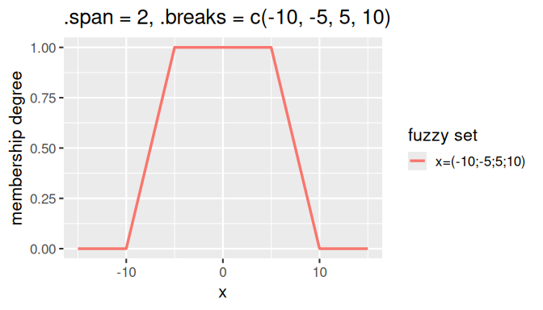

Fuzzy sets with triangular membership functions for `partition(x, .method = "triangle", .span = 2, .breaks = c(-10, -5, 5, 10))`

Additional fuzzy sets are created by shifting the window along the break points. The shift is controlled by the `.inc` argument. By default, `.inc = 1`, which means that the window shifts by one break point. Consider the following example that shows the effect of setting `.inc = 1` in addition to `.span = 2` and `.breaks = c(-15, -10, -5, 0, 5, 10, 15)`:

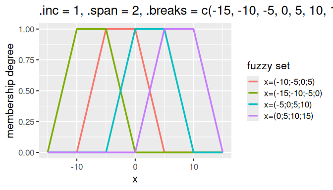

Fuzzy sets with triangular membership functions for `partition(x, .method = "triangle", .inc = 1, .span = 2, .breaks = c(-15, -10, -5, 0, 5, 10, 15))`

Setting `.inc` to a value greater than 1 modifies the shift of the window along the break points. For example, with `.inc = 3`, the window shifts by three break points, which effectively skips two fuzzy sets after each created fuzzy set:

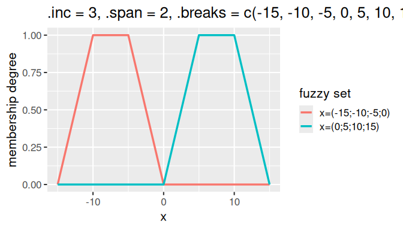

Fuzzy sets with triangular membership functions for `partition(x, .method = "triangle", .inc = 3, .span = 2, .breaks = c(-15, -10, -5, 0, 5, 10, 15))`

# Identifying and Removing Uninformative Columns

When preparing data for pattern discovery, it is important to identify and potentially remove columns that provide little or no useful information. The `nuggets` package provides two functions for this purpose: `is_almost_constant()` and `remove_almost_constant()`.

## Testing for Almost Constant Columns

The `is_almost_constant()` function checks whether a vector contains (almost) the same value in the majority of its elements. This is useful for detecting low-variability or degenerate variables.

The function returns `TRUE` if the proportion of the most frequent value in the vector is greater than or equal to a specified threshold (default is 1.0, meaning completely constant).

```r
# Completely constant vector
is_almost_constant(c(1, 1, 1, 1, 1))
```

```
#> [1] TRUE
```

```r
# Variable vector
is_almost_constant(c(1, 2, 3, 4, 5))
```

```
#> [1] FALSE
```

```r
# Almost constant (80% are the same value)
is_almost_constant(c(1, 1, 1, 1, 2), threshold = 0.8)
```

```
#> [1] TRUE
```

```r
# Not almost constant with threshold 0.8
is_almost_constant(c(1, 1, 1, 2, 2), threshold = 0.8)
```

```
#> [1] FALSE
```

The function also handles `NA` values appropriately:

```r
# With NA values - by default NA is treated as a regular value
is_almost_constant(c(NA, NA, NA, 1, 2), threshold = 0.5)
```

```
#> [1] TRUE
```

```r
# With NA removed before computing proportions
is_almost_constant(c(NA, NA, NA, 1, 2), threshold = 0.5, na_rm = TRUE)
```

```
#> [1] TRUE
```

## Removing Almost Constant Columns

The `remove_almost_constant()` function extends `is_almost_constant()` to work on entire data frames. It tests all selected columns and removes those that are almost constant according to the specified threshold.

```r
# Create a data frame with some constant and variable columns
d <- data.frame(
  a1 = 1:10,              # variable
  a2 = c(1:9, NA),        # variable
  b1 = "b",               # constant
  b2 = NA,                # constant (all NA)
  c1 = rep(c(TRUE, FALSE), 5),  # variable
  c2 = rep(c(TRUE, NA), 5),     # 50% TRUE, 50% NA
  d  = c(rep(TRUE, 4), rep(FALSE, 4), NA, NA)  # 40% TRUE, 40% FALSE, 20% NA
)

# Remove columns that are completely constant
remove_almost_constant(d, .threshold = 1.0, .na_rm = FALSE)
```

```
#> # A tibble: 10 × 5
#>       a1    a2 c1    c2    d
#>    <int> <int> <lgl> <lgl> <lgl>
#>  1     1     1 TRUE  TRUE  TRUE
#>  2     2     2 FALSE NA    TRUE
#>  3     3     3 TRUE  TRUE  TRUE
#>  4     4     4 FALSE NA    TRUE
#>  5     5     5 TRUE  TRUE  FALSE
#>  6     6     6 FALSE NA    FALSE
#>  7     7     7 TRUE  TRUE  FALSE
#>  8     8     8 FALSE NA    FALSE
#>  9     9     9 TRUE  TRUE  NA
#> 10    10    NA FALSE NA    NA
```

```r
# Remove columns where the majority value occurs in >= 50% of rows
remove_almost_constant(d, .threshold = 0.5, .na_rm = FALSE)
```

```
#> # A tibble: 10 × 3
#>       a1    a2 d
#>    <int> <int> <lgl>
#>  1     1     1 TRUE
#>  2     2     2 TRUE
#>  3     3     3 TRUE
#>  4     4     4 TRUE
#>  5     5     5 FALSE
#>  6     6     6 FALSE
#>  7     7     7 FALSE
#>  8     8     8 FALSE
#>  9     9     9 NA
#> 10    10    NA NA
```

```r
# Same as above, but removing NA before computing proportions
remove_almost_constant(d, .threshold = 0.5, .na_rm = TRUE)
```

```
#> # A tibble: 10 × 2
#>       a1    a2
#>    <int> <int>
#>  1     1     1
#>  2     2     2
#>  3     3     3
#>  4     4     4
#>  5     5     5
#>  6     6     6
#>  7     7     7
#>  8     8     8
#>  9     9     9
#> 10    10    NA
```

You can also restrict the check to a subset of columns using [tidyselect expression](https://tidyselect.r-lib.org/reference/language.html) syntax:

```r
# Only check columns a1 through b2
remove_almost_constant(d, a1:b2, .threshold = 0.5, .na_rm = TRUE)
```

```
#> # A tibble: 10 × 5
#>       a1    a2 c1    c2    d
#>    <int> <int> <lgl> <lgl> <lgl>
#>  1     1     1 TRUE  TRUE  TRUE
#>  2     2     2 FALSE NA    TRUE
#>  3     3     3 TRUE  TRUE  TRUE
#>  4     4     4 FALSE NA    TRUE
#>  5     5     5 TRUE  TRUE  FALSE
#>  6     6     6 FALSE NA    FALSE
#>  7     7     7 TRUE  TRUE  FALSE
#>  8     8     8 FALSE NA    FALSE
#>  9     9     9 TRUE  TRUE  NA
#> 10    10    NA FALSE NA    NA
```

This function is particularly useful after applying `partition()` to a dataset. Some of the generated predicates may be (almost) constant and thus uninformative for pattern discovery. Removing them can significantly speed up the subsequent mining process.

For example:

```r
# Prepare mtcars data with partition - use fresh copy
prepared_data <- mtcars |>
    mutate(cyl = factor(cyl, levels = c(4, 6, 8), labels = c("four", "six", "eight"))) |>
    partition(cyl, vs:gear, .method = "dummy") |>
    partition(mpg:carb, .method = "crisp", .breaks = 3)

# Check for and remove any almost constant columns
prepared_data <- remove_almost_constant(prepared_data,
                                       .threshold = 0.95,
                                       .verbose = TRUE)
```

# Finding Tautologies in Data

After preparing your data with `partition()` or other methods, it can be useful to identify tautologies—rules that are always or almost always true in your dataset. The `dig_tautologies()` function helps find such patterns, which can then be used to filter out redundant conditions in subsequent pattern discovery.

## What are Tautologies?

In logic, a *tautology* is a formula that is always true regardless of data. In practice, `dig_tautologies()` finds rules with very high — but not necessarily perfect — confidence in the dataset. Such empirically near-certain rules are often called **implications** (because they describe an `A => C` relationship that almost always holds) or **axioms** (because they can be assumed to hold and used as starting assumptions for pruning). The terms *tautology*, *implication*, and *axiom* are used interchangeably in the `nuggets` documentation; the precise distinction is a matter of logical philosophy and does not affect how the functions work.

For example, in a dataset about vehicles, you might discover: - `engine_type=electric => fuel_type=electricity` (confidence ≈ 1.0) - `manual_transmission=TRUE => automatic_transmission=FALSE` (confidence = 1.0)

Such rules may or may not provide interesting insights on their own. However, they are useful as axioms: knowing them allows subsequent searches to skip redundant or entailed patterns, which both reduces clutter and speeds up the search.

## Using `dig_tautologies()`

The `dig_tautologies()` function works similarly to `dig_associations()`, but is specifically optimized for finding rules with very high confidence. It searches iteratively, using tautologies found in earlier iterations to prune the search space in later iterations.

Basic usage:

```r
# Prepare fuzzy data - use fresh copy of mtcars
fuzzy_mtcars <- mtcars |>
    mutate(cyl = factor(cyl, levels = c(4, 6, 8), labels = c("four", "six", "eight"))) |>
    partition(cyl, vs:gear, .method = "dummy") |>
    partition(mpg:carb, .method = "triangle", .breaks = 3)

# Create disjoint vector
disj <- var_names(colnames(fuzzy_mtcars))

# Find tautologies with very high confidence
tautologies <- dig_tautologies(
    fuzzy_mtcars,
    antecedent = everything(),
    consequent = everything(),
    disjoint = disj,
    min_confidence = 0.95,
    min_support = 0.1,
    max_length = 3,
    t_norm = "goguen"
)

print(tautologies)
```

```
#> # A tibble: 91 × 13
#>    antecedent            consequent  support confidence coverage conseq_support
#>    <chr>                 <chr>         <dbl>      <dbl>    <dbl>          <dbl>
#>  1 {gear=3}              {am=0}        0.469      1        0.469          0.594
#>  2 {cyl=eight}           {vs=0}        0.438      1        0.438          0.562
#>  3 {disp=(272;472;Inf)}  {vs=0}        0.177      1        0.177          0.562
#>  4 {disp=(272;472;Inf)}  {cyl=eight}   0.177      1        0.177          0.438
#>  5 {gear=5}              {am=1}        0.156      1        0.156          0.406
#>  6 {mpg=(22.2;33.9;Inf)} {cyl=four}    0.135      1        0.135          0.344
#>  7 {wt=(3.47;5.42;Inf)}  {am=0}        0.123      0.987    0.125          0.594
#>  8 {wt=(3.47;5.42;Inf)}  {vs=0}        0.125      1        0.125          0.562
#>  9 {wt=(3.47;5.42;Inf)}  {gear=3}      0.123      0.987    0.125          0.469
#> 10 {wt=(3.47;5.42;Inf)}  {cyl=eight}   0.125      1        0.125          0.438
#>     lift count antecedent_length    pp     pn    np    nn
#>    <dbl> <dbl>             <int> <dbl>  <dbl> <dbl> <dbl>
#>  1  1.68 15                    1 15    0       4     13
#>  2  1.78 14                    1 14    0       4     14
#>  3  1.78  5.68                 1  5.68 0      12.3   14
#>  4  2.29  5.68                 1  5.68 0       8.32  18
#>  5  2.46  5                    1  5    0       8     19
#>  6  2.91  4.32                 1  4.32 0       6.68  21
#>  7  1.66  3.93                 1  3.93 0.0513 15.1   12.9
#>  8  1.78  3.98                 1  3.98 0      14.0   14
#>  9  2.11  3.93                 1  3.93 0.0513 11.1   16.9
#> 10  2.29  3.98                 1  3.98 0      10.0   18
#> # ℹ 81 more rows
```

The function returns a tibble in the same format as `dig_associations()`, containing rules with their quality measures (support, confidence, etc.).

## Parameters

Key parameters for `dig_tautologies()` include:

- **`antecedent`** and **`consequent`**: Tidyselect expressions defining which columns can appear on each side of the rule.
- **`disjoint`**: A vector specifying mutually exclusive predicates (predicates that should not appear together in the same condition).
- **`min_confidence`**: The minimum confidence threshold. For tautologies, this should typically be set high (e.g., 0.9 or 0.95).
- **`min_support`**: The minimum support threshold. This ensures the tautology is based on a sufficient number of observations.
- **`max_length`**: The maximum number of predicates in the antecedent.
- **`t_norm`**: The t-norm to use for fuzzy conjunction (`"goedel"`, `"goguen"`, or `"lukas"`).

## Using Tautologies to Filter Searches

Once you’ve identified tautologies (axioms), you can use them with the `excluded` argument of `dig()` or related functions such as `dig_associations()`. The `excluded` argument accepts a list of known **implications (axioms)** in the format produced by `parse_condition()`. Each axiom is a character vector where all elements except the last form the condition (i.e. the antecedent in `dig_associations()`) and the last element is the focus (i.e. the consequent in `dig_associations()`): `c(cond1, cond2, ..., condn, focus)`.

The axioms are used to prune the search via the modus ponens inference rule: - A focus (consequent) is excluded if it can be deduced from the condition (antecedent) using the axioms (transitive deduction). - A rule is pruned entirely if any predicate in the condition (antecedent) can be deduced from the remaining condition predicates using the axioms.

To convert `dig_tautologies()` results to the `excluded` format, pass both the antecedent *and* the consequent columns to `parse_condition()`:

```r
# Convert tautologies to the excluded (axioms) format
excluded_conditions <- parse_condition(tautologies$antecedent, tautologies$consequent)

# Use in subsequent pattern search
results <- dig_associations(
    fuzzy_mtcars,
    antecedent = !starts_with("am"),
    consequent = starts_with("am"),
    disjoint = disj,
    excluded = excluded_conditions,
    min_support = 0.1,
    min_confidence = 0.8
)
```

This approach can significantly reduce computation time and help focus on genuinely interesting patterns.

# Summary

This vignette covered the essential data preparation techniques in the `nuggets` package:

1. **`partition()`**: The primary function for transforming data into crisp or fuzzy predicates, with support for various partitioning methods including:
   - Logical columns: automatic expansion into `TRUE`/`FALSE` predicates
   - Factor columns: expansion into predicates for level subsets, with the ability to merge factor levels using the `.subsets` argument
   - Numeric columns (crisp): interval-based Boolean partitioning with configurable breakpoints and data-driven `.style` methods
   - Numeric columns (fuzzy): triangular, raised-cosine, and trapezoidal fuzzy sets using `.span` and `.inc` parameters
2. **`is_almost_constant()`** and **`remove_almost_constant()`**: Utility functions for identifying and removing uninformative columns that have low variability.
3. **`dig_tautologies()`**: A function for finding data-driven implications (axioms / near-tautologies) in your data. The results can be passed to the `excluded` argument of `dig()` and related functions to prune the search space via modus ponens, speeding up discovery and focusing on genuinely interesting patterns.

With these tools, you can effectively prepare your data for pattern discovery using the various `dig_*()` functions provided by the `nuggets` package. For information on pattern discovery itself, see:

- `vignette("nuggets")` for an overview of the package and its main workflows,
- `vignette("association-rules")` for a specialized pattern family based on the `dig_associations()` function,
- `vignette("conditional-correlations")` for subgroup-based correlation analysis on numeric variables,
- `vignette("contrast-patterns")` for subgroup-based statistical comparisons of numeric variables,
- `vignette("custom-patterns")` for defining custom pattern types with `dig()`.